# Bayesian Network Assignment 1

Edoardo Gervasoni s1043824 Alberto Monaco s1043826 Marco Spanò s1045892

Import useful libraries

```r
library(tidyverse)
library(dagitty)
library(bayesianNetworks)
library(lavaan)
library(stats)
library(bnlearn)
```

```r
library(naniar)
library(ggplot2)
library(caret)
library(MLmetrics)
library(tree)
library(ROSE)
```

Read original data

```r
data_original <- read.csv(paste0("data\\HR-Employee-Attrition.csv"))
data_original <- as.data.frame(data_original)
```

Let’s start now with some preprocessing steps. We are going to assembly and generalize, through the row mean, the three variables refering to the satisfaction of the worker (enviroment, job and relationship).

Being that said, we will eliminate some variable which are redundant or useless for our purpose. For instance, over18, EmployeeCount and Standard hours have only one value. For daily, monthly and hourly rate will be consider only the feature monthly income. Obviously, Employee number is an ID, we are not going to consider it.

```r
colnames(data_original)[1] = 'Age'

data_original$Attrition <- as.numeric(ordered( data_original$Attrition,c("No","Yes")))
data_original$Attrition <- as.numeric(ifelse(data_original$Attrition == 1, 0,1))

data <- data_original %>%
  mutate(TotalSatisfaction = rowMeans(cbind(EnvironmentSatisfaction, JobSatisfaction, RelationshipSatisfaction))) %>%
  select(-c(Over18, StandardHours, EmployeeCount, EmployeeNumber, MonthlyRate, HourlyRate, DailyRate, JobInvolvement, EducationField, TrainingTimesLastYear,YearsWithCurrManager, Department, JobSatisfaction, EnvironmentSatisfaction, RelationshipSatisfaction, YearsInCurrentRole,  JobRole, PerformanceRating))



str(data)
```

```
## 'data.frame':    1470 obs. of  18 variables:
##  $ Age                    : int  41 49 37 33 27 32 59 30 38 36 ...
##  $ Attrition              : num  1 0 1 0 0 0 0 0 0 0 ...
##  $ BusinessTravel         : Factor w/ 3 levels "Non-Travel","Travel_Frequently",..: 3 2 3 2 3 2 3 3 2 3 ...
##  $ DistanceFromHome       : int  1 8 2 3 2 2 3 24 23 27 ...
##  $ Education              : int  2 1 2 4 1 2 3 1 3 3 ...
##  $ Gender                 : Factor w/ 2 levels "Female","Male": 1 2 2 1 2 2 1 2 2 2 ...
##  $ JobLevel               : int  2 2 1 1 1 1 1 1 3 2 ...
##  $ MaritalStatus          : Factor w/ 3 levels "Divorced","Married",..: 3 2 3 2 2 3 2 1 3 2 ...
##  $ MonthlyIncome          : int  5993 5130 2090 2909 3468 3068 2670 2693 9526 5237 ...
##  $ NumCompaniesWorked     : int  8 1 6 1 9 0 4 1 0 6 ...
##  $ OverTime               : Factor w/ 2 levels "No","Yes": 2 1 2 2 1 1 2 1 1 1 ...
##  $ PercentSalaryHike      : int  11 23 15 11 12 13 20 22 21 13 ...
##  $ StockOptionLevel       : int  0 1 0 0 1 0 3 1 0 2 ...
##  $ TotalWorkingYears      : int  8 10 7 8 6 8 12 1 10 17 ...
##  $ WorkLifeBalance        : int  1 3 3 3 3 2 2 3 3 2 ...
##  $ YearsAtCompany         : int  6 10 0 8 2 7 1 1 9 7 ...
##  $ YearsSinceLastPromotion: int  0 1 0 3 2 3 0 0 1 7 ...
##  $ TotalSatisfaction      : num  2.33 3 3 3.33 2.33 ...
```

Let’s look at possible missing values inside the data:

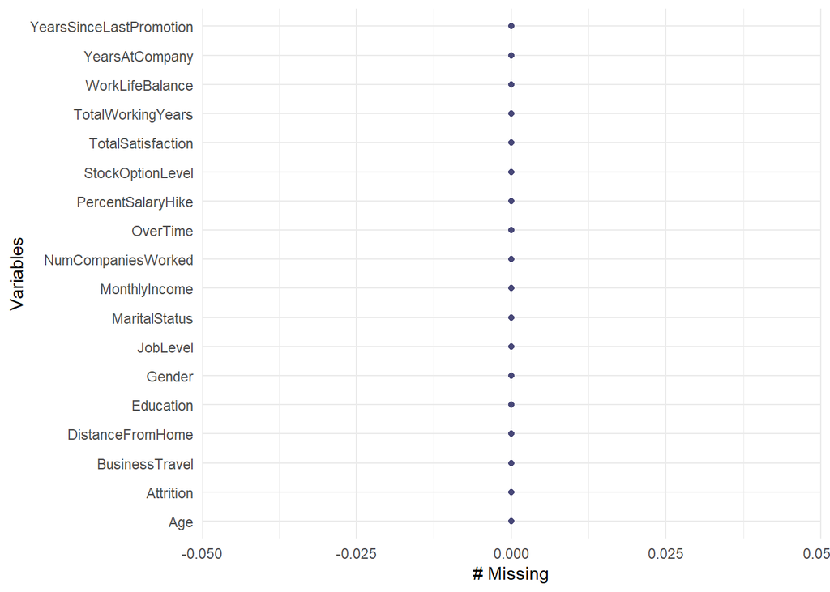

```r
gg_miss_var(data)
```

No missing among the data, let’s continue with some other preprocessing steps.

The next step will be the discretization of variables present in the data. We first need to create an order among the categories and, second, to set as binary variables the ones that do not have a proper order.

Make some variables ordered:

```r
data$JobLevel <- as.factor(data$JobLevel)
data$JobLevel <- ordered(data$JobLevel, levels = c(1,2,3,4,5))

data$WorkLifeBalance <- as.factor(data$WorkLifeBalance)
data$WorkLifeBalance <- ordered(data$WorkLifeBalance, levels = c(1,2,3,4))

data$TotalSatisfaction <- as.factor(round(data$TotalSatisfaction,0))
data$TotalSatisfaction <- ordered(data$TotalSatisfaction, levels = c(1,2,3,4))

data$Education <- as.factor(data$Education)
data$Education <- ordered(data$Education, levels = c(1,2,3,4,5))

data$StockOptionLevel <- as.factor(data$StockOptionLevel)
data$StockOptionLevel <- ordered(data$StockOptionLevel, levels = c(0,1,2,3))


data$BusinessTravel <- as.factor(data$BusinessTravel)
data$BusinessTravel <- ordered(data$BusinessTravel, levels = c("Non-Travel","Travel_Rarely","Travel_Frequently"))
```

Binary variables:

```r
data$Gender <- as.numeric(ordered( data$Gender,c("Female","Male")))
data$OverTime <- as.numeric(ordered( data$OverTime,c("No","Yes")))
```

MaritalStatus is an actually categorical variable and it cannot be ordered in a meaningful way, so we decided to make it binary by discarding the distinctions between people single and divorced.

```r
data$MaritalStatus <-as.integer( data$MaritalStatus=="Married" )
```

Once made all the variables in the appropriate way for our purporse, we can focus on data exploration.

Let’s look at the target variable’s distribution.

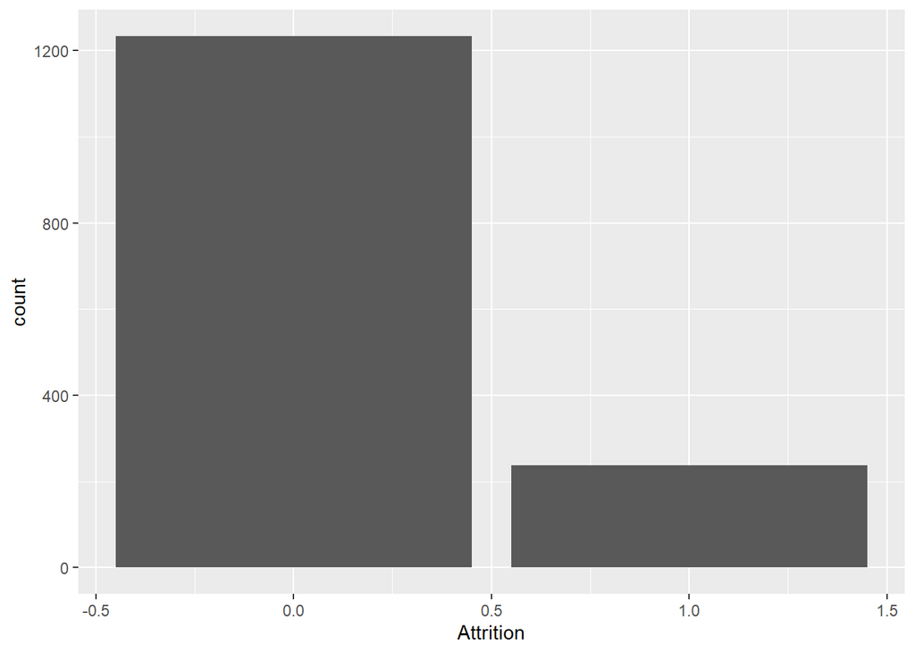

```r
data %>%
  ggplot(aes(x = Attrition)) +
  geom_histogram(stat = "count")
```

```r
data %>%
  group_by(Attrition) %>%
  summarise(n())
```

| Attrition | n() |
| --- | --- |
| 0 | 1233 |
| 1 | 237 |

Let’s look now at some possible outliers in the data:

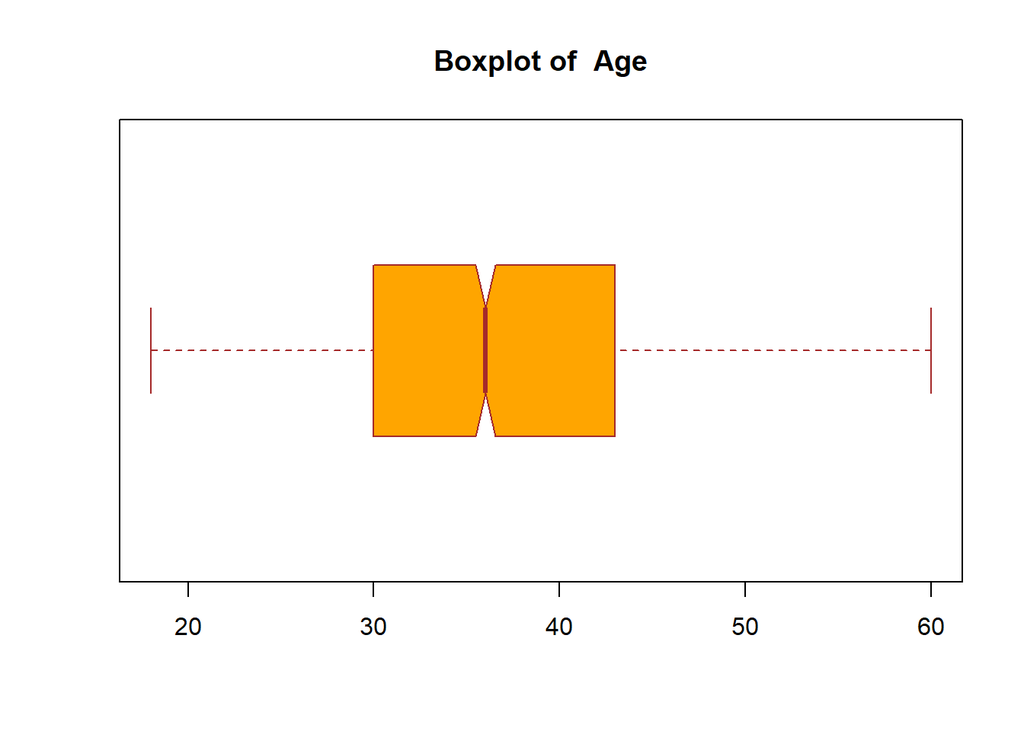

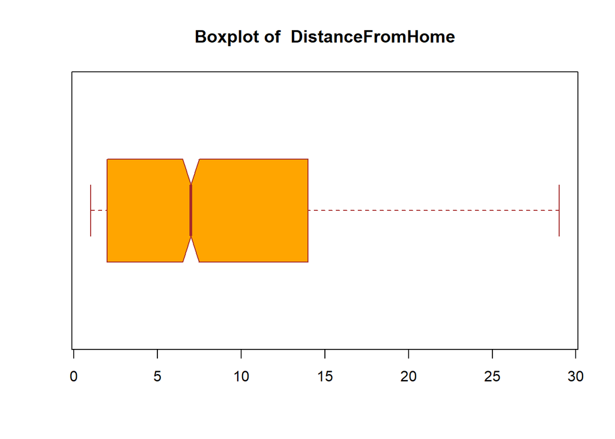

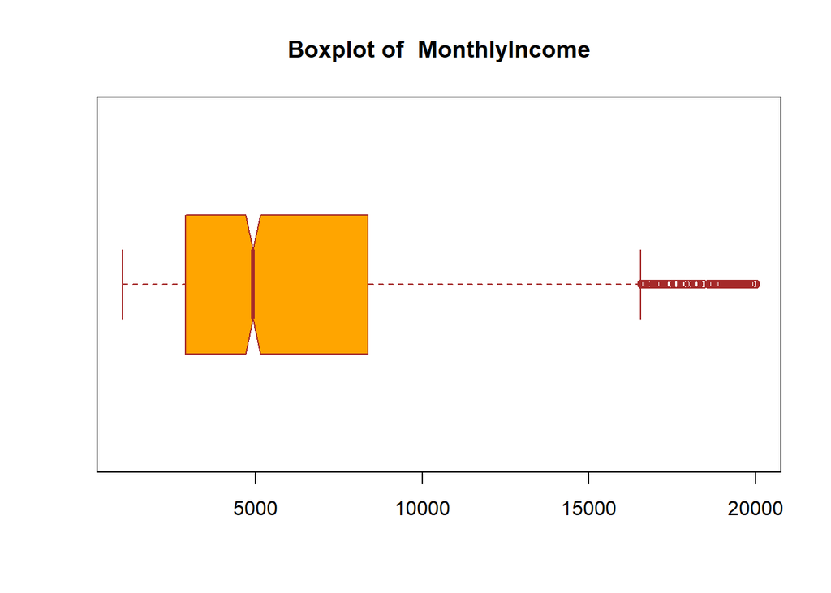

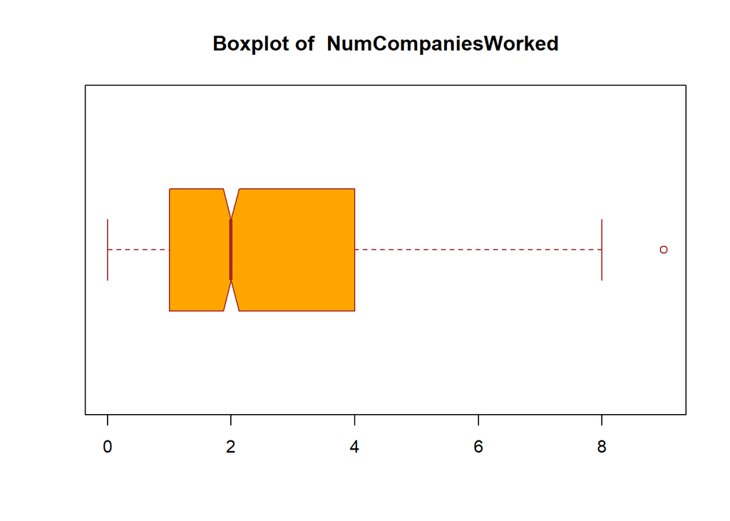

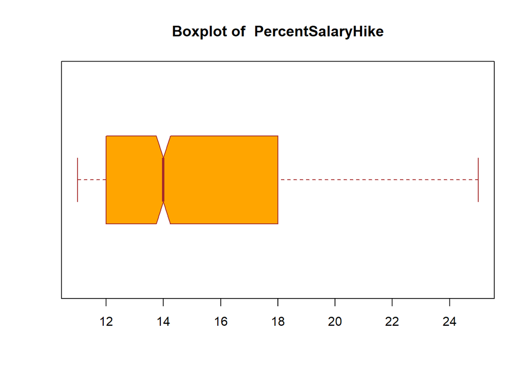

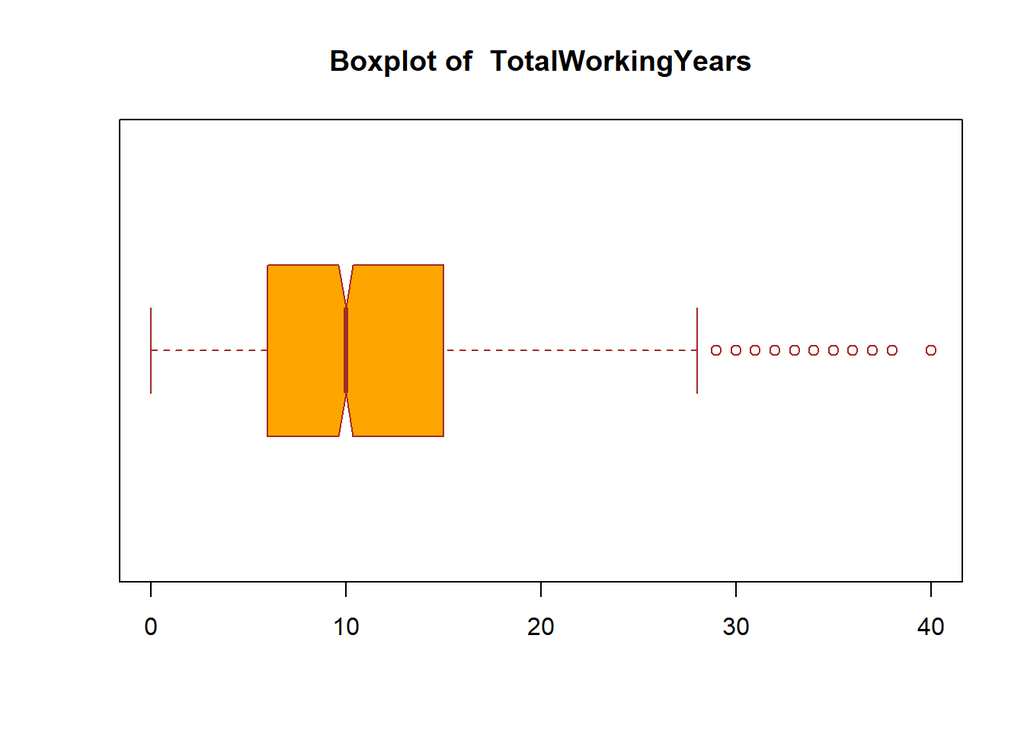

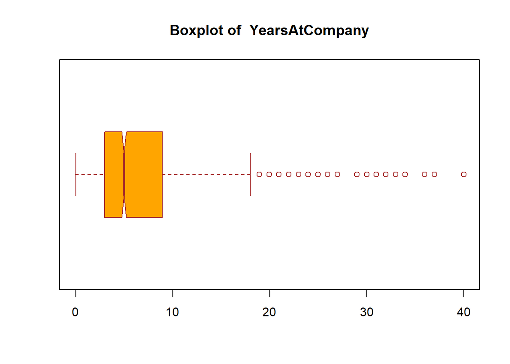

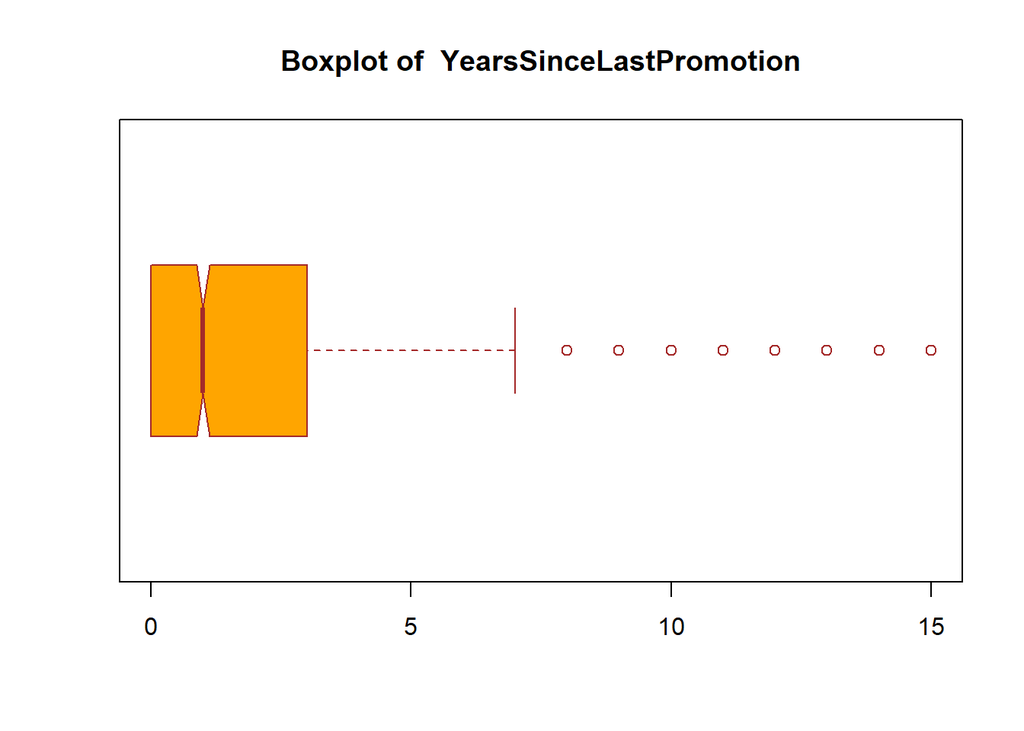

```r
numeric_variables <- c("Age", "DistanceFromHome", "MonthlyIncome", "NumCompaniesWorked", "PercentSalaryHike", "TotalWorkingYears", "YearsAtCompany", "YearsSinceLastPromotion")

for (i in numeric_variables) {
  boxplot(data[,i],
  main = paste("Boxplot of ", i),
  col = "orange",
  border = "brown",
  horizontal = TRUE,
  notch = TRUE
)
}
```

The only variable which could give us some unpleasant resutls is MontlhyIncome. It shows several outliers according to the Boxplot above. However, if we look at the range, its values go from 1009 and 19999. Now, considering the context where the data has been taken to, it is not very meaningful apply any kind of transformation. In fact, this range seems to be really common and feasible in the labour market. Moreover, transform only one variable could be misleading for the coefficents interpretation.

Since our data seem to belong to several types, We’ll extract polychoric correlation matrix, suitable to handle both categorical and continuous data:

```r
M <-lavCor(data)
M
```

```
##                         Age    Attrtn BsnssT DstnFH Eductn Gender JobLvl MrtlSt
## Age                      1.000
## Attrition               -0.159  1.000
## BusinessTravel          -0.014  0.150  1.000
## DistanceFromHome        -0.002  0.078 -0.012  1.000
## Education                0.219 -0.035 -0.012  0.023  1.000
## Gender                  -0.036  0.029 -0.054 -0.002 -0.017  1.000
## JobLevel                 0.534 -0.217 -0.019  0.020  0.130 -0.049  1.000
## MaritalStatus            0.084 -0.091  0.004  0.030  0.001 -0.008  0.055  1.000
## MonthlyIncome            0.498 -0.160 -0.015 -0.017  0.102 -0.032  0.932  0.057
## NumCompaniesWorked       0.300  0.043 -0.036 -0.029  0.130 -0.039  0.158 -0.016
## OverTime                 0.028  0.246  0.051  0.026 -0.018 -0.042 -0.002 -0.014
## PercentSalaryHike        0.004 -0.013 -0.031  0.040 -0.009  0.003 -0.035  0.021
## StockOptionLevel         0.056 -0.188 -0.035  0.048  0.021  0.014  0.042  0.289
## TotalWorkingYears        0.680 -0.171  0.010  0.005  0.157 -0.047  0.777  0.054
## WorkLifeBalance         -0.024 -0.062  0.004 -0.032  0.015 -0.001  0.051 -0.004
## YearsAtCompany           0.311 -0.134  0.006  0.010  0.075 -0.030  0.535  0.045
## YearsSinceLastPromotion  0.217 -0.033  0.006  0.010  0.058 -0.027  0.348  0.054
## TotalSatisfaction        0.053 -0.151  0.023 -0.013 -0.033  0.026  0.022 -0.058
##                         MnthlI NmCmpW OverTm PrcnSH StckOL TtlWrY WrkLfB YrsAtC
## Age
## Attrition
## BusinessTravel
## DistanceFromHome
## Education
## Gender
## JobLevel
## MaritalStatus
## MonthlyIncome            1.000
## NumCompaniesWorked       0.150  1.000
## OverTime                 0.006 -0.021  1.000
## PercentSalaryHike       -0.027 -0.010 -0.005  1.000
## StockOptionLevel         0.020  0.031 -0.004  0.016  1.000
## TotalWorkingYears        0.773  0.238  0.013 -0.021  0.025  1.000
## WorkLifeBalance          0.033 -0.004 -0.033 -0.004 -0.006  0.000  1.000
## YearsAtCompany           0.514 -0.118 -0.012 -0.036  0.029  0.628  0.012  1.000
## YearsSinceLastPromotion  0.345 -0.037 -0.012 -0.022  0.023  0.405  0.009  0.618
## TotalSatisfaction        0.006  0.006  0.086 -0.020 -0.029  0.009  0.028  0.000
##                         YrsSLP TtlSts
## Age
## Attrition
## BusinessTravel
## DistanceFromHome
## Education
## Gender
## JobLevel
## MaritalStatus
## MonthlyIncome
## NumCompaniesWorked
## OverTime
## PercentSalaryHike
## StockOptionLevel
## TotalWorkingYears
## WorkLifeBalance
## YearsAtCompany
## YearsSinceLastPromotion  1.000
## TotalSatisfaction        0.036  1.000
```

Building the first DAG:

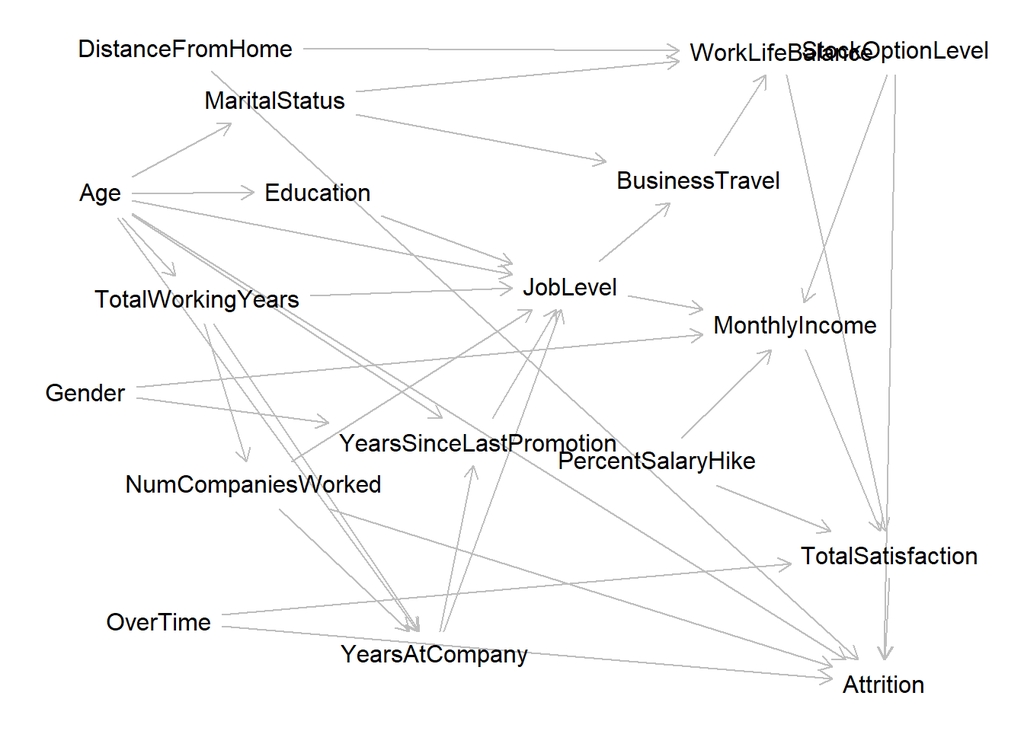

```r
graph <- dagitty('dag {
bb="-10,-10,10,10"
Age [pos="-8.492,-4.863"]
Attrition [pos="8.585,8.191"]
BusinessTravel [pos="4.548,-5.263"]
DistanceFromHome [pos="-6.647,-8.771"]
Education [pos="-3.759,-4.927"]
Gender [pos="-8.817,0.404"]
JobLevel [pos="1.740,-2.421"]
MaritalStatus [pos="-4.687,-7.383"]
MonthlyIncome [pos="6.659,-1.333"]
NumCompaniesWorked [pos="-5.151,2.912"]
OverTime [pos="-7.229,6.522"]
PercentSalaryHike [pos="3.643,2.281"]
StockOptionLevel [pos="8.837,-8.681"]
TotalSatisfaction [pos="8.724,4.766"]
TotalWorkingYears [pos="-6.381,-2.035"]
WorkLifeBalance [pos="6.357,-8.667"]
YearsAtCompany [pos="-1.206,7.439"]
YearsSinceLastPromotion [pos="-0.255,1.754"]
Age -> Attrition
Age -> Education
Age -> JobLevel
Age -> MaritalStatus
Age -> TotalWorkingYears
Age -> YearsAtCompany
Age -> YearsSinceLastPromotion
BusinessTravel -> WorkLifeBalance
DistanceFromHome -> Attrition
DistanceFromHome -> WorkLifeBalance
Education -> JobLevel
Gender -> MonthlyIncome
Gender -> YearsSinceLastPromotion
JobLevel -> BusinessTravel
JobLevel -> MonthlyIncome
MaritalStatus -> BusinessTravel
MaritalStatus -> WorkLifeBalance
MonthlyIncome -> TotalSatisfaction
NumCompaniesWorked -> Attrition
NumCompaniesWorked -> JobLevel
NumCompaniesWorked -> YearsAtCompany
OverTime -> Attrition
OverTime -> TotalSatisfaction
PercentSalaryHike -> MonthlyIncome
PercentSalaryHike -> TotalSatisfaction
StockOptionLevel -> Attrition
StockOptionLevel -> MonthlyIncome
TotalSatisfaction -> Attrition
TotalWorkingYears -> JobLevel
TotalWorkingYears -> NumCompaniesWorked
TotalWorkingYears -> YearsAtCompany
WorkLifeBalance -> TotalSatisfaction
YearsAtCompany -> JobLevel
YearsAtCompany -> YearsSinceLastPromotion
YearsSinceLastPromotion -> JobLevel
}

'
)
plot(graph)
```

Test the model using the Local Test on the polychoric correlation matrix:

```r
test_polychoric <- localTests( graph, sample.cov=M, sample.nobs=nrow(data) )
test_polychoric
```

|  | estimate | p.value | 2.5% | 97.5% |
| --- | --- | --- | --- | --- |
| Age _\|\|_ BsnT \| JbLv, MrtS | -0.0041723954 | 8.731169e-01 | -5.532290e-02 | 0.046999936 |
| Age _\|\|_ DsFH | -0.0016861201 | 9.485077e-01 | -5.280905e-02 | 0.049445619 |
| Age _\|\|_ Gndr | -0.0363105501 | 1.641169e-01 | -8.727632e-02 | 0.014844465 |
| Age _\|\|_ MntI \| Gndr, JbLv | 0.0004261662 | 9.869858e-01 | -5.073725e-02 | 0.051587349 |
| Age _\|\|_ NmCW \| TtWY | 0.1937867924 | 5.699279e-14 | 1.440740e-01 | 0.242585015 |
| Age _\|\|_ OvrT | 0.0280623571 | 2.823251e-01 | -2.309824e-02 | 0.079076565 |
| Age _\|\|_ PrSH | 0.0036335849 | 8.893141e-01 | -4.750271e-02 | 0.054750903 |
| Age _\|\|_ StOL | 0.0563703025 | 3.066794e-02 | 5.258000e-03 | 0.107189780 |
| Age _\|\|_ TtlS \| MntI, PrSH, WrLB | 0.0595138167 | 2.261796e-02 | 8.359556e-03 | 0.110358498 |
| Age _\|\|_ TtlS \| BsnT, MrtS, MntI, PrSH | 0.0622821618 | 1.706384e-02 | 1.112044e-02 | 0.113119884 |

[output cut: 264 more lines]

Fitting the model based on polychoric correlation matrix:

```r
fit <-sem(toString(graph,"lavaan"), sample.cov=M, sample.nobs=nrow(data) )
```

```r
summary(fit)
```

```
## lavaan 0.6-5 ended normally after 34 iterations
##
##   Estimator                                         ML
##   Optimization method                           NLMINB
##   Number of free parameters                         47
##
##   Number of observations                          1470
##
## Model Test User Model:
##
##   Test statistic                               514.063
##   Degrees of freedom                               103
##   P-value (Chi-square)                           0.000
##
## Parameter Estimates:
##
##   Information                                 Expected
##   Information saturated (h1) model          Structured
##   Standard errors                             Standard
##
## Regressions:
##                             Estimate  Std.Err  z-value  P(>|z|)
##   Attrition ~
##     Age                       -0.181    0.024   -7.465    0.000
##   Education ~
##     Age                        0.219    0.025    8.588    0.000
##   JobLevel ~
##     Age                        0.028    0.023    1.243    0.214
##   MaritalStatus ~
##     Age                        0.084    0.026    3.229    0.001
##   TotalWorkingYears ~
##     Age                        0.680    0.019   35.595    0.000
##   YearsAtCompany ~
##     Age                       -0.149    0.026   -5.809    0.000
##   YearsSinceLastPromotion ~
##     Age                        0.026    0.022    1.204    0.229
##   WorkLifeBalance ~
##     BusinessTravel             0.003    0.026    0.122    0.903
##   Attrition ~
##     DistanceFromHm             0.081    0.024    3.398    0.001
```

[output cut: 52 more lines]

```
##
## Variances:
##                    Estimate  Std.Err  z-value  P(>|z|)
##    .Attrition         0.833    0.031   27.111    0.000
##    .Education         0.952    0.035   27.111    0.000
##    .JobLevel          0.392    0.014   27.111    0.000
##    .MaritalStatus     0.992    0.037   27.111    0.000
##    .TotalWorkngYrs    0.537    0.020   27.111    0.000
##    .YearsAtCompany    0.518    0.019   27.111    0.000
##    .YrsSncLstPrmtn    0.616    0.023   27.111    0.000
##    .WorkLifeBalanc    0.998    0.037   27.111    0.000
##    .MonthlyIncome     0.130    0.005   27.111    0.000
##    .BusinessTravel    0.999    0.037   27.111    0.000
##    .TotalSatisfctn    0.991    0.037   27.111    0.000
##    .NumCompansWrkd    0.943    0.035   27.111    0.000
```

Looking at the results above, we decided to prune some meaningless causal relations with low estimate coefficients and high p-value. In particular these are:

age - yearsSinceLastPromotion gender - monthlyIncome Gender -YearsSinceLastPromotion JobLevel - BusinessTravel PercentSalaryHyke - MonthlyIncome

Second DAG:

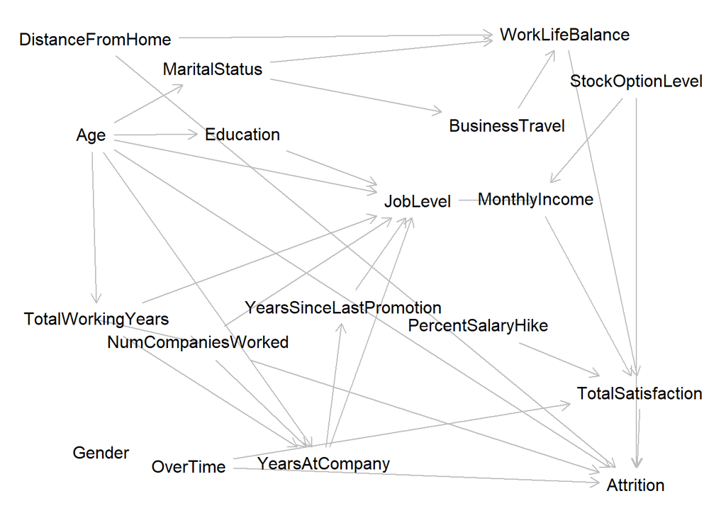

```r
graph2 <- dagitty('dag {
bb="-10,-10,10,10"
Age [pos="-8.492,-4.863"]
Attrition [pos="8.585,8.191"]
BusinessTravel [pos="4.548,-5.263"]
DistanceFromHome [pos="-8.376,-8.481"]
Education [pos="-3.759,-4.927"]
Gender [pos="-8.190,6.982"]
JobLevel [pos="1.740,-2.421"]
MaritalStatus [pos="-4.687,-7.383"]
MonthlyIncome [pos="5.452,-2.456"]
NumCompaniesWorked [pos="-5.151,2.912"]
OverTime [pos="-5.446,7.511"]
PercentSalaryHike [pos="3.643,2.281"]
StockOptionLevel [pos="8.605,-6.882"]
TotalSatisfaction [pos="8.724,4.766"]
TotalWorkingYears [pos="-8.329,2.035"]
WorkLifeBalance [pos="6.357,-8.667"]
YearsAtCompany [pos="-1.206,7.439"]
YearsSinceLastPromotion [pos="-0.580,1.544"]
Age -> Attrition
Age -> Education
Age -> JobLevel
Age -> MaritalStatus
Age -> TotalWorkingYears
Age -> YearsAtCompany
BusinessTravel -> WorkLifeBalance
DistanceFromHome -> Attrition
DistanceFromHome -> WorkLifeBalance
Education -> JobLevel
JobLevel -> MonthlyIncome
MaritalStatus -> BusinessTravel
MaritalStatus -> WorkLifeBalance
MonthlyIncome -> TotalSatisfaction
NumCompaniesWorked -> Attrition
NumCompaniesWorked -> JobLevel
NumCompaniesWorked -> YearsAtCompany
OverTime -> Attrition
OverTime -> TotalSatisfaction
PercentSalaryHike -> TotalSatisfaction
StockOptionLevel -> Attrition
StockOptionLevel -> MonthlyIncome
TotalSatisfaction -> Attrition
TotalWorkingYears -> JobLevel
TotalWorkingYears -> NumCompaniesWorked
TotalWorkingYears -> YearsAtCompany
WorkLifeBalance -> TotalSatisfaction
YearsAtCompany -> JobLevel
YearsAtCompany -> YearsSinceLastPromotion
YearsSinceLastPromotion -> JobLevel
}



')

plot(graph2)
```

Test the new model using the polychoric correlation matrix:

```r
test_polychoric2 <- localTests( graph2, sample.cov=M, sample.nobs=nrow(data) )
test_polychoric2
```

|  | estimate | p.value | 2.5% | 97.5% |
| --- | --- | --- | --- | --- |
| Age _\|\|_ BsnT \| MrtS | -1.399947e-02 | 5.919226e-01 | -0.0650977982 | 0.037172011 |
| Age _\|\|_ DsFH | -1.686120e-03 | 9.485077e-01 | -0.0528090514 | 0.049445619 |
| Age _\|\|_ Gndr | -3.631055e-02 | 1.641169e-01 | -0.0872763201 | 0.014844465 |
| Age _\|\|_ MntI \| JbLv | -3.146254e-05 | 9.990388e-01 | -0.0511762644 | 0.051113504 |
| Age _\|\|_ NmCW \| TtWY | 1.937868e-01 | 5.699279e-14 | 0.1440740035 | 0.242585015 |
| Age _\|\|_ OvrT | 2.806236e-02 | 2.823251e-01 | -0.0230982401 | 0.079076565 |
| Age _\|\|_ PrSH | 3.633585e-03 | 8.893141e-01 | -0.0475027125 | 0.054750903 |
| Age _\|\|_ StOL | 5.637030e-02 | 3.066794e-02 | 0.0052580000 | 0.107189780 |
| Age _\|\|_ TtlS \| MntI, WrLB | 5.910862e-02 | 2.351013e-02 | 0.0079704387 | 0.109939508 |
| Age _\|\|_ TtlS \| MrtS, MntI | 6.175569e-02 | 1.794599e-02 | 0.0106269846 | 0.112563536 |

[output cut: 217 more lines]

```r
fit2 <-sem(toString(graph2,"lavaan"), sample.cov=M, sample.nobs=nrow(data) )
```

```r
summary(fit2)
```

```
## lavaan 0.6-5 ended normally after 31 iterations
##
##   Estimator                                         ML
##   Optimization method                           NLMINB
##   Number of free parameters                         43
##
##   Number of observations                          1470
##
## Model Test User Model:
##
##   Test statistic                               523.598
##   Degrees of freedom                               113
##   P-value (Chi-square)                           0.000
##
## Parameter Estimates:
##
##   Information                                 Expected
##   Information saturated (h1) model          Structured
##   Standard errors                             Standard
##
## Regressions:
##                             Estimate  Std.Err  z-value  P(>|z|)
##   Attrition ~
##     Age                       -0.181    0.024   -7.465    0.000
##   Education ~
##     Age                        0.219    0.025    8.588    0.000
##   JobLevel ~
##     Age                        0.028    0.023    1.243    0.214
##   MaritalStatus ~
##     Age                        0.084    0.026    3.229    0.001
##   TotalWorkingYears ~
##     Age                        0.680    0.019   35.595    0.000
##   YearsAtCompany ~
##     Age                       -0.149    0.026   -5.809    0.000
##   WorkLifeBalance ~
##     BusinessTravel             0.003    0.026    0.122    0.903
##   Attrition ~
##     DistanceFromHm             0.081    0.024    3.398    0.001
##   WorkLifeBalance ~
##     DistanceFromHm            -0.032    0.026   -1.215    0.224
```

[output cut: 42 more lines]

```
## Variances:
##                    Estimate  Std.Err  z-value  P(>|z|)
##     Gender            0.999    0.037   27.111    0.000
##    .Attrition         0.833    0.031   27.111    0.000
##    .Education         0.952    0.035   27.111    0.000
##    .JobLevel          0.392    0.014   27.111    0.000
##    .MaritalStatus     0.992    0.037   27.111    0.000
##    .TotalWorkngYrs    0.537    0.020   27.111    0.000
##    .YearsAtCompany    0.518    0.019   27.111    0.000
##    .WorkLifeBalanc    0.998    0.037   27.111    0.000
##    .MonthlyIncome     0.130    0.005   27.111    0.000
##    .BusinessTravel    0.999    0.037   27.111    0.000
##    .TotalSatisfctn    0.991    0.037   27.111    0.000
##    .NumCompansWrkd    0.943    0.035   27.111    0.000
##    .YrsSncLstPrmtn    0.617    0.023   27.111    0.000
```

In this DAG still remain some relations with high p-value and low estimate coefficients with also a controversial causation. Thus we decided to remove:

WorkLifeBalance - BusinessTravel BusinessTravel - MaritialStatus WorkLifeBalance - MaritialStatus TotalSatisfaction - MonthlyIncome JobLevel - NumCompaniesWorked JobLevel - YearsSinceLastPromotion

Finally, we mantained the relationship between Education and JobLevel even if they appear to be not linear related from the data. That’s because we think these two features are casually linked.

Third DAG:

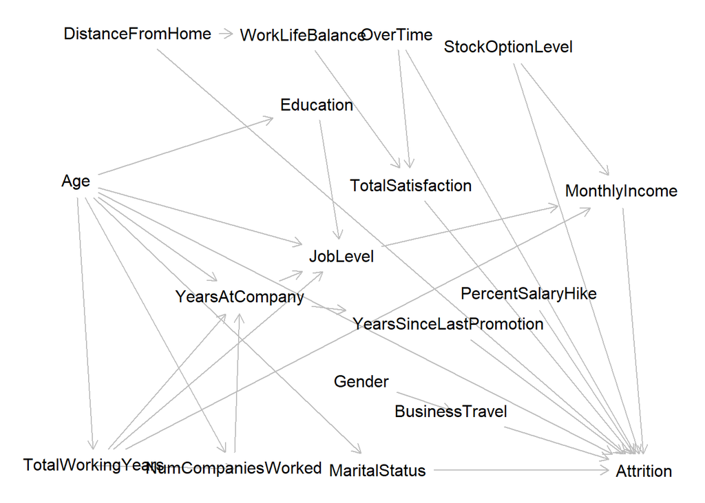

```r
graph3 <- dagitty('dag {
bb="-10,-10,10,10"
Age [pos="-9.128,-3.073"]
Attrition [pos="8.585,8.191"]
BusinessTravel [pos="2.558,5.866"]
DistanceFromHome [pos="-7.209,-8.883"]
Education [pos="-1.624,-6.105"]
Gender [pos="-0.232,4.702"]
JobLevel [pos="-0.853,-0.196"]
MaritalStatus [pos="0.278,8.175"]
MonthlyIncome [pos="7.868,-2.682"]
NumCompaniesWorked [pos="-4.200,8.140"]
OverTime [pos="0.853,-8.855"]
PercentSalaryHike [pos="4.981,1.313"]
StockOptionLevel [pos="4.341,-8.324"]
TotalSatisfaction [pos="1.318,-2.961"]
TotalWorkingYears [pos="-8.566,8.017"]
WorkLifeBalance [pos="-2.054,-8.827"]
YearsAtCompany [pos="-4.031,1.453"]
YearsSinceLastPromotion [pos="2.483,2.456"]
Age -> Attrition
Age -> Education
Age -> JobLevel
Age -> MaritalStatus
Age -> NumCompaniesWorked
Age -> TotalWorkingYears
Age -> YearsAtCompany
BusinessTravel -> Attrition
DistanceFromHome -> Attrition
DistanceFromHome -> WorkLifeBalance
Education -> JobLevel
Gender -> BusinessTravel
JobLevel -> MonthlyIncome
MaritalStatus -> Attrition
MonthlyIncome -> Attrition
NumCompaniesWorked -> YearsAtCompany
OverTime -> Attrition
OverTime -> TotalSatisfaction
PercentSalaryHike -> Attrition
StockOptionLevel -> Attrition
StockOptionLevel -> MonthlyIncome
TotalSatisfaction -> Attrition
TotalWorkingYears -> JobLevel
TotalWorkingYears -> MonthlyIncome
TotalWorkingYears -> NumCompaniesWorked
TotalWorkingYears -> YearsAtCompany
WorkLifeBalance -> TotalSatisfaction
YearsAtCompany -> JobLevel
YearsAtCompany -> YearsSinceLastPromotion
YearsSinceLastPromotion -> Attrition
}


')

plot(graph3)
```

Testing the conditional independencies of the DAG using polychoric correlation matrix:

```r
test_polychoric3 <- localTests( graph3, sample.cov=M, sample.nobs=nrow(data) )
test_polychoric3
```

|  | estimate | p.value | 2.5% | 97.5% |
| --- | --- | --- | --- | --- |
| Age _\|\|_ BsnT | -1.364994e-02 | 6.010824e-01 | -0.0647322916 | 0.037503700 |
| Age _\|\|_ DsFH | -1.686120e-03 | 9.485077e-01 | -0.0528090514 | 0.049445619 |
| Age _\|\|_ Gndr | -3.631055e-02 | 1.641169e-01 | -0.0872763201 | 0.014844465 |
| Age _\|\|_ MntI \| JbLv, TtWY | -1.262949e-01 | 1.174276e-06 | -0.1763294277 | -0.075621460 |
| Age _\|\|_ OvrT | 2.806236e-02 | 2.823251e-01 | -0.0230982401 | 0.079076565 |
| Age _\|\|_ PrSH | 3.633585e-03 | 8.893141e-01 | -0.0475027125 | 0.054750903 |
| Age _\|\|_ StOL | 5.637030e-02 | 3.066794e-02 | 0.0052580000 | 0.107189780 |
| Age _\|\|_ TtlS | 5.331690e-02 | 4.094840e-02 | 0.0021954276 | 0.104161239 |
| Age _\|\|_ WrLB | -2.391597e-02 | 3.595669e-01 | -0.0749519340 | 0.027244804 |
| Age _\|\|_ YSLP \| YrAC | 3.213318e-02 | 2.184160e-01 | -0.0190429759 | 0.083141669 |

[output cut: 127 more lines]

Fitting the DAG

```r
fit3 <-sem(toString(graph3,"lavaan"), sample.cov=M, sample.nobs=nrow(data) )

summary(fit3)
```

```
## lavaan 0.6-5 ended normally after 25 iterations
##
##   Estimator                                         ML
##   Optimization method                           NLMINB
##   Number of free parameters                         42
##
##   Number of observations                          1470
##
## Model Test User Model:
##
##   Test statistic                               358.310
##   Degrees of freedom                               108
##   P-value (Chi-square)                           0.000
##
## Parameter Estimates:
##
##   Information                                 Expected
##   Information saturated (h1) model          Structured
##   Standard errors                             Standard
##
## Regressions:
##                             Estimate  Std.Err  z-value  P(>|z|)
##   Attrition ~
##     Age                       -0.091    0.028   -3.254    0.001
##   Education ~
##     Age                        0.219    0.025    8.588    0.000
##   JobLevel ~
##     Age                        0.027    0.023    1.169    0.242
##   MaritalStatus ~
##     Age                        0.084    0.026    3.229    0.001
##   NumCompaniesWorked ~
##     Age                        0.257    0.034    7.573    0.000
##   TotalWorkingYears ~
##     Age                        0.680    0.019   35.595    0.000
##   YearsAtCompany ~
##     Age                       -0.149    0.026   -5.699    0.000
##   Attrition ~
##     BusinessTravel             0.132    0.024    5.624    0.000
##     DistanceFromHm             0.078    0.024    3.307    0.001
##   WorkLifeBalance ~
```

[output cut: 39 more lines]

```
##
## Variances:
##                    Estimate  Std.Err  z-value  P(>|z|)
##    .Attrition         0.815    0.030   27.111    0.000
##    .Education         0.952    0.035   27.111    0.000
##    .JobLevel          0.392    0.014   27.111    0.000
##    .MaritalStatus     0.992    0.037   27.111    0.000
##    .NumCompansWrkd    0.907    0.033   27.111    0.000
##    .TotalWorkngYrs    0.537    0.020   27.111    0.000
##    .YearsAtCompany    0.518    0.019   27.111    0.000
##    .WorkLifeBalanc    0.998    0.037   27.111    0.000
##    .BusinessTravel    0.996    0.037   27.111    0.000
##    .MonthlyIncome     0.124    0.005   27.111    0.000
##    .TotalSatisfctn    0.991    0.037   27.111    0.000
##    .YrsSncLstPrmtn    0.617    0.023   27.111    0.000
```

Frome the results obtained, we can see that most of the edges of our final DAG are significative. In particular we have found several important estimates:

MonthlyIncome ~ JobLevel; TotalWorkingYears ~ Age; YearsAtCompany ~ TotalWorkngYrs; JobLevel ~ TotalWorkngYrs; YearsSinceLastPromotion ~ YearsAtCompany;

All of these have an estimate coefficient of at least 0.60 and are positively correlated, as well as logically casual associated.

We decided to keep the relation between JobLevel - Education and PercentSalaryHike - Attrition, despite having a bad results according to the data we have, because of strong causal relation between these variables in the real world. We should consider that the relations shown in the results are linear. It could be possible that Education and JobLevel or PercentSalaryHike and Attrition are linked in a non-linear way (e.g. a quadratic, exponential, etc.).

In order to perform a prediction task we cannot use the Polychoric Correlation. So, we are going to split the data into training and test set, keep subset of the variables which are relevant based on DAG and exploit them to perform a classification model on the target variables. Once built up the model and we will use it to make prediction.

One way we can perform is test predictions try to forecast a node from its parents.

So, we are going to subset the variables, choosing the ones that are directly correlated with the target variable Attrition:

```r
data_prediction <- data_original %>%
  mutate(TotalSatisfaction = rowMeans(cbind(EnvironmentSatisfaction, JobSatisfaction, RelationshipSatisfaction))) %>%
  select(c(Attrition, TotalSatisfaction, BusinessTravel, MonthlyIncome, PercentSalaryHike, MaritalStatus, YearsSinceLastPromotion, OverTime, DistanceFromHome, Age, StockOptionLevel))
```

```r
data_prediction$MaritalStatus <-as.integer( data_prediction$MaritalStatus=="Married" )

set.seed(123)
train_index <- createDataPartition(data_prediction$Attrition, p = 0.67, list = FALSE)

train_set <- data_prediction[train_index, ]
test_set <- data_prediction[-train_index, ]
```

Let’s perform now a logistic model:

```r
mod_logistic <-glm(Attrition ~ ., family =  "binomial", data = train_set)
summary(mod_logistic)
```

```
##
## Call:
## glm(formula = Attrition ~ ., family = "binomial", data = train_set)
##
## Deviance Residuals:
##     Min       1Q   Median       3Q      Max
## -1.6600  -0.5710  -0.3564  -0.1732   3.4186
##
## Coefficients:
##                                   Estimate Std. Error z value Pr(>|z|)
## (Intercept)                      1.969e+00  8.379e-01   2.350 0.018762 *
## TotalSatisfaction               -8.759e-01  1.619e-01  -5.411 6.26e-08 ***
## BusinessTravelTravel_Frequently  1.428e+00  4.472e-01   3.193 0.001409 **
## BusinessTravelTravel_Rarely      6.631e-01  4.224e-01   1.570 0.116461
## MonthlyIncome                   -1.440e-04  3.581e-05  -4.021 5.78e-05 ***
## PercentSalaryHike               -1.766e-02  2.680e-02  -0.659 0.509952
## MaritalStatus                   -3.171e-01  2.058e-01  -1.540 0.123445
## YearsSinceLastPromotion          5.646e-02  3.626e-02   1.557 0.119429
## OverTimeYes                      1.484e+00  2.045e-01   7.258 3.94e-13 ***
## DistanceFromHome                 3.304e-02  1.210e-02   2.730 0.006329 **
## Age                             -4.511e-02  1.368e-02  -3.297 0.000977 ***
## StockOptionLevel                -4.643e-01  1.319e-01  -3.521 0.000430 ***
## ---
## Signif. codes:  0 '***' 0.001 '**' 0.01 '*' 0.05 '.' 0.1 ' ' 1
##
## (Dispersion parameter for binomial family taken to be 1)
##
##     Null deviance: 857.48  on 984  degrees of freedom
## Residual deviance: 680.84  on 973  degrees of freedom
## AIC: 704.84
##
## Number of Fisher Scoring iterations: 6
```

```r
prediction_logistic <- predict(mod_logistic, type="response", test_set)
prediction_logistic <- ifelse(prediction_logistic > 0.5, 1, 0)
```

```r
P <- Precision(test_set$Attrition, prediction_logistic)
R <- Recall(test_set$Attrition, prediction_logistic)
print(paste('Precision: ', P))
```

```
## [1] "Precision:  0.864628820960699"
```

```r
print(paste('Recall: ', R))
```

```
## [1] "Recall:  0.982630272952854"
```

```r
print(paste('F1measure :', (2 * P * R) / (P + R)))
```

```
## [1] "F1measure : 0.9198606271777"
```

```r
print(paste('Accuracy :' , Accuracy(test_set$Attrition, prediction_logistic)))
```

```
## [1] "Accuracy : 0.857731958762887"
```

```r
print(paste('AUC :' , AUC(test_set$Attrition, prediction_logistic)))
```

```
## [1] "AUC : 0.80268478085072"
```

The results achieved are affected by the problem known as Class Unbalanced.

Thus, in order to correct this issue, we are going to oversample the data:

```r
data_prediciton_over <- ovun.sample(Attrition ~ ., data = data_prediction, method = "over")$data

set.seed(123)
train_index <- createDataPartition(data_prediciton_over$Attrition, p = 0.67, list = FALSE)

train_set <- data_prediciton_over[train_index, ]
test_set <- data_prediciton_over[-train_index, ]
```

```r
mod_logistic_over <-glm(Attrition ~ ., family =  "binomial", data = train_set)
summary(mod_logistic_over)
```

```
##
## Call:
## glm(formula = Attrition ~ ., family = "binomial", data = train_set)
##
## Deviance Residuals:
##     Min       1Q   Median       3Q      Max
## -2.2600  -0.8980  -0.2129   0.8686   2.4649
##
## Coefficients:
##                                   Estimate Std. Error z value Pr(>|z|)
## (Intercept)                      2.105e+00  4.675e-01   4.503 6.69e-06 ***
## TotalSatisfaction               -8.743e-01  9.336e-02  -9.364  < 2e-16 ***
## BusinessTravelTravel_Frequently  1.761e+00  2.653e-01   6.638 3.19e-11 ***
## BusinessTravelTravel_Rarely      1.306e+00  2.414e-01   5.410 6.32e-08 ***
## MonthlyIncome                   -9.541e-05  1.690e-05  -5.645 1.66e-08 ***
## PercentSalaryHike               -1.998e-02  1.589e-02  -1.258 0.208390
## MaritalStatus                   -1.608e-01  1.225e-01  -1.313 0.189112
## YearsSinceLastPromotion          4.523e-02  2.039e-02   2.218 0.026569 *
## OverTimeYes                      1.573e+00  1.235e-01  12.738  < 2e-16 ***
## DistanceFromHome                 3.085e-02  7.065e-03   4.366 1.27e-05 ***
## Age                             -2.481e-02  7.154e-03  -3.467 0.000525 ***
## StockOptionLevel                -4.662e-01  7.142e-02  -6.527 6.71e-11 ***
## ---
## Signif. codes:  0 '***' 0.001 '**' 0.01 '*' 0.05 '.' 0.1 ' ' 1
##
## (Dispersion parameter for binomial family taken to be 1)
##
##     Null deviance: 2287.3  on 1649  degrees of freedom
## Residual deviance: 1810.9  on 1638  degrees of freedom
## AIC: 1834.9
##
## Number of Fisher Scoring iterations: 4
```

```r
prediction_logistic_over <- predict(mod_logistic_over, type="response", test_set)
prediction_logistic_over <- ifelse(prediction_logistic_over > 0.5, 1, 0)
```

```r
P <- Precision(test_set$Attrition, prediction_logistic_over)
R <- Recall(test_set$Attrition, prediction_logistic_over)
print(paste('Precision: ', P))
```

```
## [1] "Precision:  0.764397905759162"
```

```r
print(paste('Recall: ', R))
```

```
## [1] "Recall:  0.724565756823821"
```

```r
print(paste('F1measure :', (2 * P * R) / (P + R)))
```

```
## [1] "F1measure : 0.743949044585987"
```

```r
print(paste('Accuracy :' , Accuracy(test_set$Attrition, prediction_logistic_over)))
```

```
## [1] "Accuracy : 0.752463054187192"
```

```r
print(paste('AUC :' , AUC(test_set$Attrition, prediction_logistic_over)))
```

```
## [1] "AUC : 0.753129185437721"
```

All the standard evaluation measures seem to give us helpful results.

One clever approach can be implement a logistic regression, based on the stepwise selection criterion.

```r
library(MASS)
step.model <- stepAIC(mod_logistic_over, direction = "backward", trace = FALSE)
summary(step.model)
```

```
##
## Call:
## glm(formula = Attrition ~ TotalSatisfaction + BusinessTravel +
##     MonthlyIncome + YearsSinceLastPromotion + OverTime + DistanceFromHome +
##     Age + StockOptionLevel, family = "binomial", data = train_set)
##
## Deviance Residuals:
##     Min       1Q   Median       3Q      Max
## -2.2775  -0.9153  -0.2257   0.8883   2.4320
##
## Coefficients:
##                                   Estimate Std. Error z value Pr(>|z|)
## (Intercept)                      1.791e+00  3.927e-01   4.560 5.12e-06 ***
## TotalSatisfaction               -8.701e-01  9.320e-02  -9.336  < 2e-16 ***
## BusinessTravelTravel_Frequently  1.762e+00  2.655e-01   6.635 3.25e-11 ***
## BusinessTravelTravel_Rarely      1.304e+00  2.412e-01   5.408 6.39e-08 ***
## MonthlyIncome                   -9.404e-05  1.676e-05  -5.610 2.02e-08 ***
## YearsSinceLastPromotion          4.356e-02  2.026e-02   2.150 0.031521 *
## OverTimeYes                      1.567e+00  1.231e-01  12.729  < 2e-16 ***
## DistanceFromHome                 3.001e-02  7.029e-03   4.269 1.96e-05 ***
## Age                             -2.596e-02  7.115e-03  -3.649 0.000263 ***
## StockOptionLevel                -4.935e-01  6.886e-02  -7.167 7.66e-13 ***
## ---
## Signif. codes:  0 '***' 0.001 '**' 0.01 '*' 0.05 '.' 0.1 ' ' 1
##
## (Dispersion parameter for binomial family taken to be 1)
##
##     Null deviance: 2287.3  on 1649  degrees of freedom
## Residual deviance: 1814.2  on 1640  degrees of freedom
## AIC: 1834.2
##
## Number of Fisher Scoring iterations: 4
```

Both classic linear logistic regression and stepwise logistic agree with the results achieved with the fitting carried out by the polychoric correlation matrix. Indeed, PercentSalaryHike is considered as useless to get affect the attrition attitude of employees, while yearsSinceLastPromotion is the less significative.

Let’s look at the prediction carried out by the stepwise logistic model:

```r
prediction_step <- predict(step.model, type="response", test_set)
prediction_step <- ifelse(prediction_step > 0.5, 1, 0)
```

```r
P <- Precision(test_set$Attrition, prediction_step)
R <- Recall(test_set$Attrition, prediction_step)
print(paste('Precision: ', P))
```

```
## [1] "Precision:  0.761273209549072"
```

```r
print(paste('Recall: ', R))
```

```
## [1] "Recall:  0.712158808933002"
```

```r
print(paste('F1measure :', (2 * P * R) / (P + R)))
```

```
## [1] "F1measure : 0.735897435897436"
```

```r
print(paste('Accuracy :' , Accuracy(test_set$Attrition, prediction_step)))
```

```
## [1] "Accuracy : 0.746305418719212"
```

```r
print(paste('AUC :' , AUC(test_set$Attrition, prediction_step)))
```

```
## [1] "AUC : 0.747303271441202"
```

Let’s go ahead with one more classification model: Decision Tree

```r
decision_tree <- tree(Attrition ~ . , data = train_set)
summary(decision_tree)
```

```
##
## Regression tree:
## tree(formula = Attrition ~ ., data = train_set)
## Variables actually used in tree construction:
## [1] "OverTime"                "Age"
## [3] "StockOptionLevel"        "TotalSatisfaction"
## [5] "MonthlyIncome"           "DistanceFromHome"
## [7] "BusinessTravel"          "PercentSalaryHike"
## [9] "YearsSinceLastPromotion"
## Number of terminal nodes:  13
## Residual mean deviance:  0.173 = 283.2 / 1637
## Distribution of residuals:
##    Min. 1st Qu.  Median    Mean 3rd Qu.    Max.
## -0.9138 -0.2202 -0.1687  0.0000  0.1833  0.8313
```

```r
decision_tree
```

```
## node), split, n, deviance, yval
##       * denotes terminal node
##
##   1) root 1650 412.500 0.4970
##     2) OverTime: No 1009 235.600 0.3717
##       4) Age < 33.5 483 120.700 0.5114
##         8) StockOptionLevel < 0.5 276  62.610 0.6522
##          16) TotalSatisfaction < 1.83333 58   4.569 0.9138 *
##          17) TotalSatisfaction > 1.83333 218  53.010 0.5826
##            34) MonthlyIncome < 2059.5 47   5.234 0.8723 *
##            35) MonthlyIncome > 2059.5 171  42.750 0.5029
##              70) DistanceFromHome < 10.5 109  25.820 0.3853
##               140) BusinessTravel: Non-Travel,Travel_Rarely 73  13.560 0.2466 *
##               141) BusinessTravel: Travel_Frequently 36   8.000 0.6667 *
##              71) DistanceFromHome > 10.5 62  12.770 0.7097
##               142) PercentSalaryHike < 14.5 19   4.105 0.3158 *
##               143) PercentSalaryHike > 14.5 43   4.419 0.8837 *
##         9) StockOptionLevel > 0.5 207  45.310 0.3237 *
##       5) Age > 33.5 526  96.850 0.2433
##        10) YearsSinceLastPromotion < 13.5 504  86.550 0.2202 *
##        11) YearsSinceLastPromotion > 13.5 22   3.864 0.7727 *
##     3) OverTime: Yes 641 136.100 0.6942
##       6) StockOptionLevel < 0.5 371  55.540 0.8167 *
##       7) StockOptionLevel > 0.5 270  67.320 0.5259
##        14) MonthlyIncome < 4984.5 163  35.040 0.6871 *
##        15) MonthlyIncome > 4984.5 107  21.590 0.2804
##          30) DistanceFromHome < 21 83  11.640 0.1687 *
##          31) DistanceFromHome > 21 24   5.333 0.6667 *
```

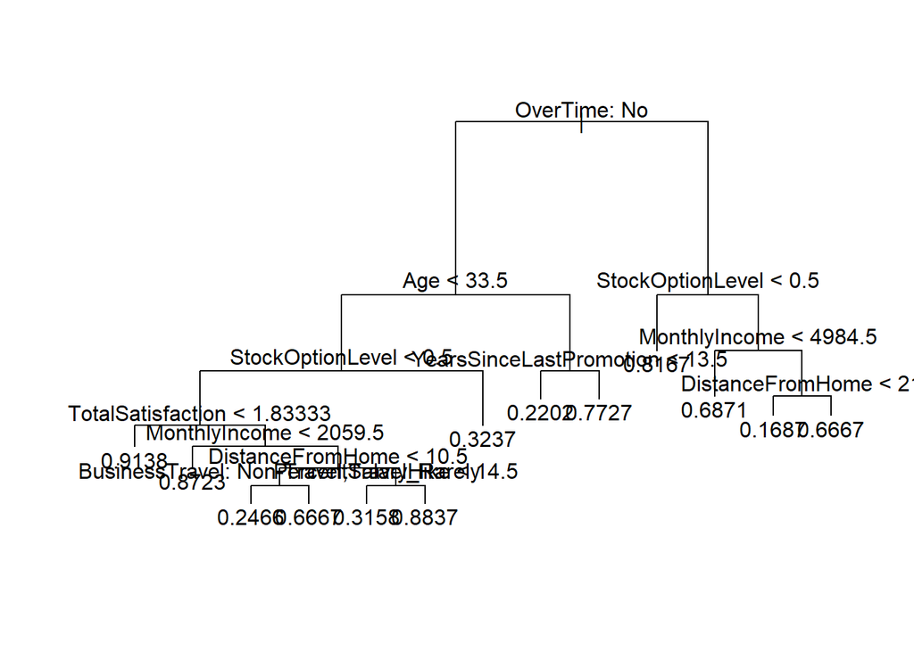

```r
plot(decision_tree)
text(decision_tree, pretty = 0)
```

```r
tree_prediction = predict(decision_tree, test_set)
tree_prediction <- ifelse(tree_prediction >0.5,1,0)
```

```r
P <- Precision(test_set$Attrition, tree_prediction)
R <- Recall(test_set$Attrition, tree_prediction)
print(paste('Precision: ', P))
```

```
## [1] "Precision:  0.727272727272727"
```

```r
print(paste('Recall: ', R))
```

```
## [1] "Recall:  0.794044665012407"
```

```r
print(paste('F1measure :', (2 * P * R) / (P + R)))
```

```
## [1] "F1measure : 0.759193357058126"
```

```r
print(paste('Accuracy :' , Accuracy(test_set$Attrition, tree_prediction)))
```

```
## [1] "Accuracy : 0.75"
```

```r
print(paste('AUC :' , AUC(test_set$Attrition, tree_prediction)))
```

```
## [1] "AUC : 0.752077223851417"
```

```r
prediction_logistic_over <- as.factor(prediction_logistic_over)
prediction_step <- as.factor(prediction_step)
tree_prediction <- as.factor(tree_prediction)
```

```r
test_set$Attrition <- as.factor(test_set$Attrition)
```

Let’s look now the confusion matrix of the 3 models performed:

```r
confusionMatrix(prediction_logistic_over,test_set$Attrition,positive='1')
```

```
## Confusion Matrix and Statistics
##
##           Reference
## Prediction   0   1
##          0 292  90
##          1 111 319
##
##                Accuracy : 0.7525
##                  95% CI : (0.7213, 0.7818)
##     No Information Rate : 0.5037
##     P-Value [Acc > NIR] : <2e-16
##
##                   Kappa : 0.5047
##
##  Mcnemar's Test P-Value : 0.1583
##
##             Sensitivity : 0.7800
##             Specificity : 0.7246
##          Pos Pred Value : 0.7419
##          Neg Pred Value : 0.7644
##              Prevalence : 0.5037
##          Detection Rate : 0.3929
##    Detection Prevalence : 0.5296
##       Balanced Accuracy : 0.7523
##
##        'Positive' Class : 1
##
```

```r
confusionMatrix(prediction_step,test_set$Attrition,positive='1')
```

```
## Confusion Matrix and Statistics
##
##           Reference
## Prediction   0   1
##          0 287  90
##          1 116 319
##
##                Accuracy : 0.7463
##                  95% CI : (0.7149, 0.7759)
##     No Information Rate : 0.5037
##     P-Value [Acc > NIR] : < 2e-16
##
##                   Kappa : 0.4923
##
##  Mcnemar's Test P-Value : 0.08154
##
##             Sensitivity : 0.7800
##             Specificity : 0.7122
##          Pos Pred Value : 0.7333
##          Neg Pred Value : 0.7613
##              Prevalence : 0.5037
##          Detection Rate : 0.3929
##    Detection Prevalence : 0.5357
##       Balanced Accuracy : 0.7461
##
##        'Positive' Class : 1
##
```

```r
confusionMatrix(tree_prediction,test_set$Attrition,positive='1')
```

```
## Confusion Matrix and Statistics
##
##           Reference
## Prediction   0   1
##          0 320 120
##          1  83 289
##
##                Accuracy : 0.75
##                  95% CI : (0.7187, 0.7794)
##     No Information Rate : 0.5037
##     P-Value [Acc > NIR] : < 2e-16
##
##                   Kappa : 0.5003
##
##  Mcnemar's Test P-Value : 0.01151
##
##             Sensitivity : 0.7066
##             Specificity : 0.7940
##          Pos Pred Value : 0.7769
##          Neg Pred Value : 0.7273
##              Prevalence : 0.5037
##          Detection Rate : 0.3559
##    Detection Prevalence : 0.4581
##       Balanced Accuracy : 0.7503
##
##        'Positive' Class : 1
##
```

Considering the simplicity of the models tried above, we can state that the predictions show good results. Moreover, we should consider as fundamental factor, the matching between our DAG and the results got with the linear models above.